# getPairs-Funktion im RecordLinkage-Package

Omar Besic, Thierry Schmidt, Chantal Zbinden

5/25/2019

### RecordLinkage package

Provides functions for linking and de-duplicating data sets.  
Methods based on a stochastic approach are implemented as well as classification algorithms  
from the machine learning domain.

### Data analysis

dataframe of 500 persons  
with firstname, second firstname, lastname, second lastname, birthyear, birthmonth and birthday

```r
data(RLdata500)
head(RLdata500)
```

```
##   fname_c1 fname_c2 lname_c1 lname_c2   by bm bd
## 1  CARSTEN     <NA>    MEIER     <NA> 1949  7 22
## 2     GERD     <NA>    BAUER     <NA> 1968  7 27
## 3   ROBERT     <NA> HARTMANN     <NA> 1930  4 30
## 4   STEFAN     <NA>    WOLFF     <NA> 1957  9  2
## 5     RALF     <NA>  KRUEGER     <NA> 1966  1 13
## 6  JUERGEN     <NA>   FRANKE     <NA> 1929  7  4
```

### Building pairs on RLdata500 dataset

using compare.dedup to generate record pairs for deduplication or linkage.  
The summary shows 124’750 combinations based on the 500 datasets.  
There are no matching statuses because weight was not setted at this moment.

```r
summary(compare.dedup(RLdata500))
```

```
##
## Deduplication Data Set
##
## 500 records
## 124750 record pairs
##
## 0 matches
## 0 non-matches
## 124750 pairs with unknown status
```

blockfld aliviates the problem of n*(n-1)/2 and compares at least one of the field of 1,3,5,6,7  
(compare columns 1, 3 or, 5 up to 7 for two records to qualify to become a pair)  
with help of levenshteinSim formula we can compare the strings.

```r
rec.pairs <- compare.dedup(RLdata500
                           ,blockfld = list(1, 3, 5:7)
                           ,strcmp = c(2,3,4)
                           ,strcmpfun = levenshteinSim)
```

rec.pairs is list and there is dataframe of name pairs which is created in compare.dedup  
assign dataframe rec.pairs$pairs to matches

```r
matches <- rec.pairs$pairs
```

give me the matches of all rows on which the restriction had be defined in blockfld for 1 = same | 0 = not same

```r
head(matches)
```

```
##   id1 id2 fname_c1 fname_c2  lname_c1 lname_c2 by bm bd is_match
## 1   1   8        0       NA 1.0000000       NA  0  0  0       NA
## 2   1  64        0       NA 1.0000000       NA  0  1  0       NA
## 3   1 141        0       NA 1.0000000       NA  0  0  0       NA
## 4   1 174        1       NA 0.1428571       NA  0  0  0       NA
## 5   1 185        0       NA 1.0000000       NA  0  0  0       NA
## 6   1 204        1       NA 0.0000000       NA  0  0  0       NA
```

### Example 1 of pairs generated

show pair in row 2 (id1: 1, id2: 64) show patient in row 1 show patient in row 64

```r
matches[2,]
```

```
##   id1 id2 fname_c1 fname_c2 lname_c1 lname_c2 by bm bd is_match
## 2   1  64        0       NA        1       NA  0  1  0       NA
```

```r
RLdata500[1,]
```

```
##   fname_c1 fname_c2 lname_c1 lname_c2   by bm bd
## 1  CARSTEN     <NA>    MEIER     <NA> 1949  7 22
```

```r
RLdata500[64,]
```

```
##    fname_c1 fname_c2 lname_c1 lname_c2   by bm bd
## 64  JUERGEN     <NA>    MEIER     <NA> 1983  7  7
```

### Example 2 of pairs generated

show pair in row 13 (id1: 2, id2: 43) show patient in row 2 show patient in row 43

```r
matches[13,]
```

```
##    id1 id2 fname_c1 fname_c2  lname_c1 lname_c2 by bm bd is_match
## 13   2  43        1       NA 0.8333333       NA  1  1  1       NA
```

```r
RLdata500[2,]
```

```
##   fname_c1 fname_c2 lname_c1 lname_c2   by bm bd
## 2     GERD     <NA>    BAUER     <NA> 1968  7 27
```

```r
RLdata500[43,]
```

```
##    fname_c1 fname_c2 lname_c1 lname_c2   by bm bd
## 43     GERD     <NA>   BAUERH     <NA> 1968  7 27
```

```r
#?compare.dedup()
rec.pairs <- compare.dedup(RLdata500,blockfld = list(1, 3, 5:7),strcmp = c(2,3,4),strcmpfun = levenshteinSim)
summary(rec.pairs)
```

```
##
## Deduplication Data Set
##
## 500 records
## 3465 record pairs
##
## 0 matches
## 0 non-matches
## 3465 pairs with unknown status
```

### Vorgehen 2: Add weight calculation

**1. Variante mit epiWeight:**“Calculates weights for record paris based on the EpiLink approach”

Werte von 0 bis 1

**2. Variante mit emWeight:**“Calculates weights for Record Linkage based on an EM algorithm”

Werte von -10 bis 35

#### epiWeight in example

```r
rec.pairs <- epiWeights(rec.pairs)
length(rec.pairs$pairs$id1) #Anzahl Pairs
```

```
## [1] 3465
```

```r
length(rec.pairs$Wdata) #Anzahl Weights
```

```
## [1] 3465
```

```r
head(rec.pairs$Wdata) #Overview of data rparis - weights
```

```
## [1] 0.1843473 0.2819983 0.1843473 0.2225780 0.1843473 0.1962427
```

For each pair a weight has been calculated

#### Histogramm of epiWeight

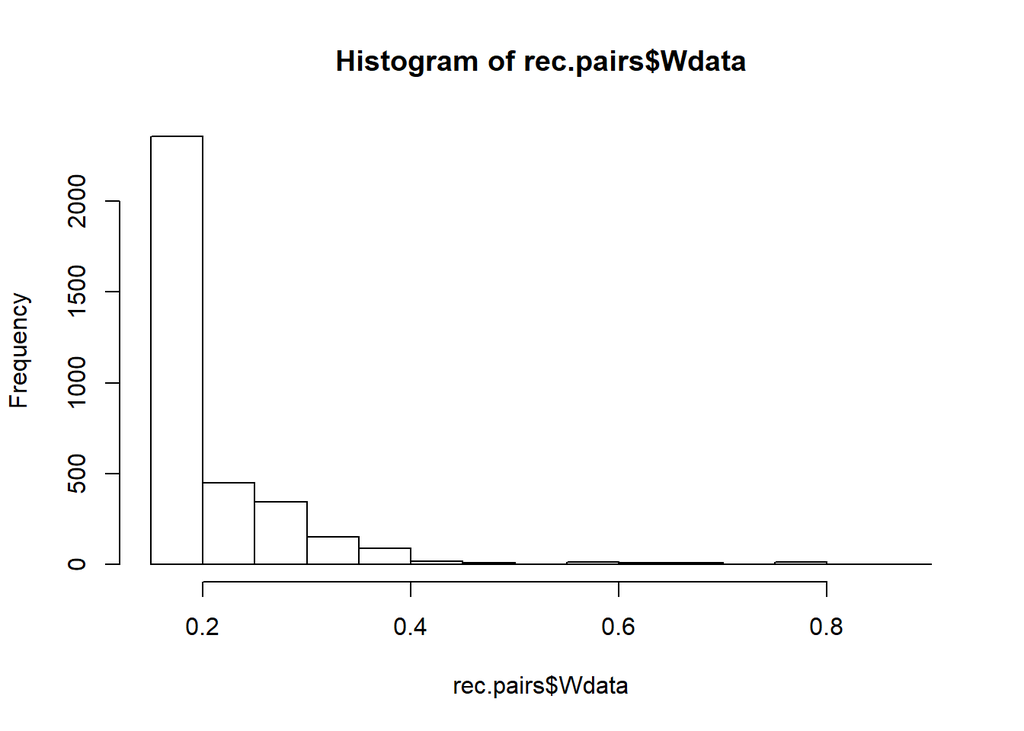

```r
hist(rec.pairs$Wdata)
```

### Vorgehen 3: getPairs

show paris with the weights of them

use filter on weights

```r
head(getPairs(rec.pairs, min.weight=0.5, max.weight=0.6)) #show all record pairs with weights between 0.5 and 0.6
```

```
##    id fname_c1 fname_c2 lname_c1 lname_c2   by bm bd    Weight
## 1  48   WERNER     <NA>  KOERTIG     <NA> 1965 11 28
## 2 238  WERNIER     <NA>  KOERTIG     <NA> 1965 11 28 0.5924569
## 3
## 4  68   PETEVR     <NA>    FUCHS     <NA> 1972  9 12
## 5 190    PETER     <NA>    FUCHS     <NA> 1972  9 12 0.5924569
## 6
```

```r
tail(getPairs(rec.pairs, min.weight=0.5, max.weight=0.6))
```

```
##     id fname_c1 fname_c2 lname_c1 lname_c2   by bm bd    Weight
## 43  37 HARTMHUT     <NA> HOFFMSNN     <NA> 1929 12 29
## 44  72  HARTMUT     <NA> HOFFMANN     <NA> 1929 12 29 0.5694135
## 45
## 46 388   ANDREA     <NA>    WEBER     <NA> 1945  5 20
## 47 408   ANDREA     <NA>  SCHMIDT     <NA> 1945  2 20 0.5067013
## 48
```

```r
rpairs <- getPairs(rec.pairs, single.rows=FALSE) #generate pairs of data.frame rec.pairs
length(rpairs$id) #not number of pairs, if single.row = FALSE, because 1 pairs use 3 rows
```

```
## [1] 10395
```

### Vorgehen 4: Classification

“To select with”show" in getPairs() function, you need first to Classify your dataset with epiClassify() or emClassify() depending your approach (epiWeight or emWeight)"

**emClassify:** Classifies data pairs to which weights were assigned by **emWeights**. Based on user-defined threholds or predefined error rates

Two general approaches are implemented. The classical procedure by Fellegi and Sunter minimizes the number of possible links with given error levels for false links (my) and false non-links (ny).

The second approach requires threholds for links and possible links to be set by the user. A pair with weight w is classified as a link if w >= threshold.upper, as a possible link if threhold.upper >= w >= threshold.lower and as a non-link if w < threshold.lower.

If threshold.upper or threshold.lower is given, the threshold-based approach is used, otherwise, if one of the error bounds is given, the Fellegi-Sunter model. If only my is supplied, links are chosen to meet the error bound and all other pairs are classified as non-links (the equivalent case holds if only ny is specified). If no further arguments than rpairs are given, a single threshold of 0 is used.

The quality of classification of the Fellegi-Sunter method relies strongly on resonable estimations of m- and u-probabilities. The results should be evaluated critically.

**epClassify:**

Neue Variablen: prediction und threshold

Threshold.upper –> Schwellenwet ab wann Pairs zu links werden

Threshold.under –> Schwellenwert ab wann non-links zu possible links werden

Possible prediction-levels: non-linked and linked (no possible’s because only threshold.upper defined)

If no threshold.under is defined; treshold.under = treshold.upper

```r
cldata <- epiClassify(rec.pairs, 0.5) #threshold.lower = threshold.upper if not defined
summary(cldata$prediction)
```

```
##    N    P    L
## 3416    0   49
```

```r
cldata <- epiClassify(rec.pairs, 0.6, 0.4)
summary(cldata$prediction)
```

```
##    N    P    L
## 3388   44   33
```

```r
head(getPairs(cldata, show="links", single.rows=FALSE)) #now we can filter, show="links", "nonlinks", "possible" or "all"
```

```
##    id fname_c1 fname_c2 lname_c1 lname_c2   by bm bd    Weight
## 1 313   URSULA   BIRGIT  MUELLRR     <NA> 1940  6 15
## 2 457   URSULA   BIRGIT  MUELLER     <NA> 1940  6 15 0.8873649
## 3
## 4 467   ULRIKE   NICOLE   BECKRR     <NA> 1982  8  4
## 5 472   ULRIKE   NICOLE   BECKER     <NA> 1982  8  4 0.8829756
## 6
```

### False matches and false non-matches

Now we can check which of the pairs are false-negative and which are false-positive. In other words, which of these pairs form synonyms (false-negative) or homonyms (false-positive)?

Therefore we use the RLBigDataDedup method, add weights with the epi aproach and weight them by 0.5

```r
data(RLdata500)
testdata <- RLdata500
data <- RLBigDataDedup(testdata, identity = identity.RLdata500,
                       blockfld=list(1,3,5:7),
                       strcmp = c(2,3,4),
                       strcmpfun = "levenshtein")
data <- epiWeights(data)
result <- epiClassify(data, 0.5)
```

**Synonym:**

Example: Martin and Maeddae: same person is meant, but the pair does not form a link.  
Give me all synonyms based on my weight of 0.5

```r
 getFalseNeg(result)
```

```
##    id fname_c1 fname_c2 lname_c1 lname_c2   by bm bd is_match Class
## 1 353     INGE     <NA>   SEIDEL     <NA> 1949  9  4
## 2 355    INGEU     <NA>   SEIDEL     <NA> 1949  8  4     TRUE     N
## 3
## 4 285    ERIKA     <NA>    WEBER     <NA> 1995  2  1
## 5 379    ERIKA     <NA>    WEBER     <NA> 1992  2 29     TRUE     N
## 6
##      Weight
## 1
## 2 0.4948059
## 3
## 4
## 5 0.4782410
## 6
```

**Homonym:**

Example: Jan and Jan: not the same person, but the pair forms a link because string is the same.

```r
 getFalsePos(result)
```

```
##    id fname_c1 fname_c2 lname_c1 lname_c2   by bm bd is_match Class
## 1 388   ANDREA     <NA>    WEBER     <NA> 1945  5 20
## 2 408   ANDREA     <NA>  SCHMIDT     <NA> 1945  2 20    FALSE     L
## 3
##      Weight
## 1
## 2 0.5067013
## 3
```

### Fragestellung

“Dear Professor Sariyar: I am using your great tools to do matching. I got a quick question: In getPairs (matcher or links), we have filter.match = c(”match“,”unknown“,”nonmatch“), filter.link = c(”nonlink“,”possible“,”link“), do we have any ways to calculate theri confidence levels related? Thanks and best regards…”

### Threshold determination

#### 1. Clerical Review

#### 2. getParetoThreshold

Calculates a classification threshold based on a generalized Pareto distribution fitted to the weights distribution of the given data pairs

#### 3. optimalThreshold

Calculates the optimal threshold for weight-based RecordLinkage

- my = error bound for false positives
- ny = error bound for false negatives